# Practical Machine Learning/ Prediction Assignment

## Background

Using devices such as Jawbone Up, Nike FuelBand, and Fitbit it is now possible to collect a large amount of data about personal activity relatively inexpensively. These type of devices are part of the quantified self movement – a group of enthusiasts who take measurements about themselves regularly to improve their health, to find patterns in their behavior, or because they are tech geeks. One thing that people regularly do is quantify how much of a particular activity they do, but they rarely quantify how well they do it. In this project, your goal will be to use data from accelerometers on the belt, forearm, arm, and dumbell of 6 participants. They were asked to perform barbell lifts correctly and incorrectly in 5 different ways. More information is available from the website here: http://groupware.les.inf.puc-rio.br/har (see the section on the Weight Lifting Exercise Dataset).

## Data

The training data for this project are available here:

https://d396qusza40orc.cloudfront.net/predmachlearn/pml-training.csv

The test data are available here:

https://d396qusza40orc.cloudfront.net/predmachlearn/pml-testing.csv

```r
downloadcsv <- function(url, nastrings) {
    temp <- tempfile()
    download.file(url, temp, method = "curl")
    data <- read.csv(temp, na.strings = nastrings)
    unlink(temp)
    return(data)
}

trainurl <- "https://d396qusza40orc.cloudfront.net/predmachlearn/pml-training.csv"
trainingOrg <- downloadcsv(trainurl, c("", "NA", "#DIV/0!"))

testurl <- "https://d396qusza40orc.cloudfront.net/predmachlearn/pml-testing.csv"
testingOrg <- downloadcsv(testurl, c("", "NA", "#DIV/0!"))
```

Check the training and testing data

```r
dim(trainingOrg)
```

```
## [1] 19622   160
```

```r
dim(testingOrg)
```

```
## [1]  20 160
```

Load libraries

```r
library(caret)
library(randomForest)
library(grDevices)
```

## Data Preprocessing

- Remove variables (columns) where we find too many rows with NA

```r
trainingComp <- trainingOrg[ , colSums(is.na(trainingOrg)) == 0]
dim(trainingComp)
```

```
## [1] 19622    60
```

- Remove variables that we do not expect to be relevant (such as username, timestamp, etc..)

```r
trainingCore <- trainingComp[, -which(names(trainingComp) %in% c('X', 'user_name', 'raw_timestamp_part_1', 'raw_timestamp_part_2', 'cvtd_timestamp', 'new_window', 'num_window'))]
dim(trainingCore)
```

```
## [1] 19622    53
```

- Review if there are any variables strongly correlated. To be fancy we can visualize correlation with heat map.

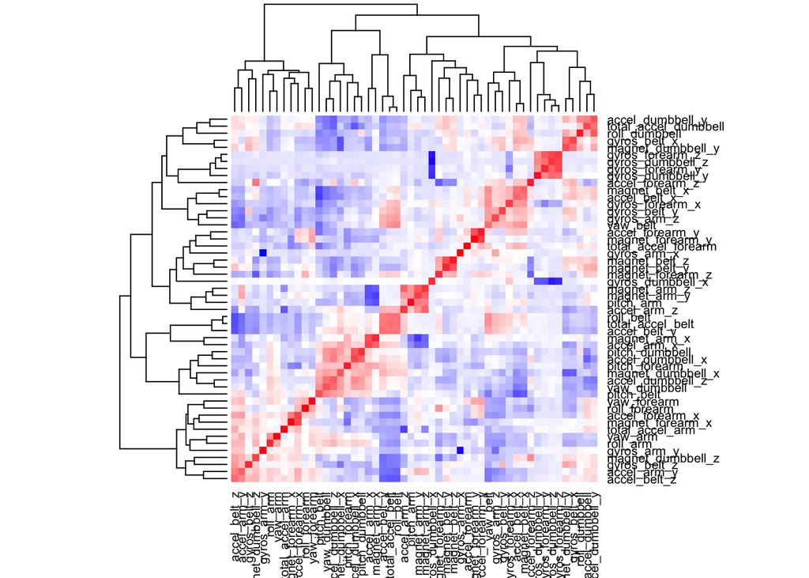

```r
predcorr <- cor(trainingCore[, names(trainingCore) != 'classe'])
pal <- colorRampPalette(c('blue', 'white', 'red'))(n = 199)
heatmap(predcorr, col = pal)
```

- As shown above most of variables are not strongly correlated.
- We can remove those that are correlated in 90% or more.

```r
corrMatrix <- cor(na.omit(trainingCore[sapply(trainingCore, is.numeric)])) ## correlation table
trainingUncore <- trainingCore[,-findCorrelation(corrMatrix, cutoff = .90, verbose = TRUE)] ## use table to remove variables strongly correlated
```

```
## Compare row 10  and column  1 with corr  0.992
##   Means:  0.27 vs 0.168 so flagging column 10
## Compare row 1  and column  9 with corr  0.925
##   Means:  0.25 vs 0.164 so flagging column 1
## Compare row 9  and column  4 with corr  0.928
##   Means:  0.233 vs 0.161 so flagging column 9
## Compare row 8  and column  2 with corr  0.966
##   Means:  0.245 vs 0.157 so flagging column 8
## Compare row 19  and column  18 with corr  0.918
##   Means:  0.091 vs 0.158 so flagging column 18
## Compare row 46  and column  31 with corr  0.914
##   Means:  0.101 vs 0.161 so flagging column 31
## Compare row 46  and column  33 with corr  0.933
##   Means:  0.083 vs 0.164 so flagging column 33
## All correlations <= 0.9
```

```r
dim(trainingUncore)
```

```
## [1] 19622    46
```

In the end we will workj with all 19622 samples and use 46 variables.

## Predictive Model

Split data into training and testing

```r
set.seed(1210)
inTrain <- createDataPartition(y=trainingUncore$classe, p=0.7, list=FALSE)
training <- trainingUncore[inTrain,]
testing <- trainingUncore[-inTrain,]
dim(training)
```

```
## [1] 13737    46
```

```r
dim(testing)
```

```
## [1] 5885   46
```

I will use Random Forest algorithm. I will limit number of trees to 200.

```r
model <- randomForest(classe~.,data=training,ntree=200, importance=TRUE)
model
```

```
##
## Call:
##  randomForest(formula = classe ~ ., data = training, ntree = 200,      importance = TRUE)
##                Type of random forest: classification
##                      Number of trees: 200
## No. of variables tried at each split: 6
##
##         OOB estimate of  error rate: 0.69%
## Confusion matrix:
##      A    B    C    D    E class.error
## A 3901    4    0    0    1 0.001280082
## B   15 2632   11    0    0 0.009781791
## C    0   15 2378    3    0 0.007512521
## D    0    0   35 2215    2 0.016429840
## E    0    1    3    5 2516 0.003564356
```

Crossvalidate the model using remaining 30% of data.

```r
predictCrossVal <- predict(model, testing)
confusionMatrix(testing$classe, predictCrossVal)
```

```
## Confusion Matrix and Statistics
##
##           Reference
## Prediction    A    B    C    D    E
##          A 1674    0    0    0    0
##          B   11 1120    8    0    0
##          C    0    4 1020    2    0
##          D    0    0    8  956    0
##          E    0    0    0    4 1078
##
## Overall Statistics
##
##                Accuracy : 0.9937
##                  95% CI : (0.9913, 0.9956)
##     No Information Rate : 0.2863
##     P-Value [Acc > NIR] : < 2.2e-16
##
##                   Kappa : 0.992
##  Mcnemar's Test P-Value : NA
##
## Statistics by Class:
##
##                      Class: A Class: B Class: C Class: D Class: E
## Sensitivity            0.9935   0.9964   0.9846   0.9938   1.0000
## Specificity            1.0000   0.9960   0.9988   0.9984   0.9992
## Pos Pred Value         1.0000   0.9833   0.9942   0.9917   0.9963
## Neg Pred Value         0.9974   0.9992   0.9967   0.9988   1.0000
## Prevalence             0.2863   0.1910   0.1760   0.1635   0.1832
## Detection Rate         0.2845   0.1903   0.1733   0.1624   0.1832
## Detection Prevalence   0.2845   0.1935   0.1743   0.1638   0.1839
## Balanced Accuracy      0.9967   0.9962   0.9917   0.9961   0.9996
```

This is a good model with 99% accuracy.

## Testing Model on another data set

Test model on the test data set downloaded frmo the second file:

```r
answers <- predict(model, testingOrg)
answers
```

```
##  1  2  3  4  5  6  7  8  9 10 11 12 13 14 15 16 17 18 19 20
##  B  A  B  A  A  E  D  B  A  A  B  C  B  A  E  E  A  B  B  B
## Levels: A B C D E
```